# A Jupyter Book Template for Research-Based Open Educational Resources in Data Literacy

Hannes Schnaitter¹, Evgenia Samoilova², Lamia Islam²

¹Humboldt-Universität zu Berlin; ²Universität Potsdam

# Agenda

**Requirements**

**Jupyter Book**

**The Template**

**Future Work**

# Requirements

**Context QUADRIGA**

**Instructional Design**

**Usage Scenarios**

**(Executable) Code**

**Openness**

## Context QUADRIGA

- 12 case studies across multiple author teams
- different requirements based on specific audience and focused competencies
- consistency between case studies with allowances for individualization
- project based learning demonstrates applicability and usefulness of material to learners

## Instructional Design

Support for the core components identified by (Samoilova et al. 2024):

1. Presentation of Questions/Problems/Tasks
2. Supporting Information
3. Interactive Exercises
4. Summary and Reflection
5. Procedural Information
6. Assessment

## Usage Scenarios

**focus on doctoral students, post-docs and other scientists**

### Learning

- **ease of use**
- **flexibility of learning**
- **levels of engagement:**
  - reading
  - interacting on the website
  - interacting with code
  - making code your own

### Teaching

- **ease of reuse**
  - useful content and exercises
  - extracting parts and adapting them should be easy

### Writing

- **ease of modification**
  - enable authors to realize their intent
  - easy to use after short introduction

## (Executable) Code

- integration of code examples and their results
- choice of programming language
- similarity to real “research environment”

## Openness

- Open Educational Resource
- Open Formats
- No special execution environment / runtime prerequisites
- Development can be observed and contributed to
- Open Source

**Practice what you preach.**

# Jupyter Book

## Alternatives

- Moodle
- Quarto
- LiaScript
- Folder(s) of Jupyter Notebooks

## Jupyter Book Characteristics

- static site generator
- structure of content and links between pages
- Jupyter Notebooks (`.ipynb`) and Markdown (`.md`) files
- clear bi-directional connection between source files and pages of website

# The Template

## Architecture

**File Structure**

**Building the Book**

### File Structure

**Configuration files**

```
/_config.yml      # Jupyter Book configuration
/_toc.yml         # Jupyter Book Table of Contents (ToC)
```

**Building the Book**

```
/requirements.txt # Python requirements. Other requirements based for other kernels possible.
/.github/         # GitHub configuration for Actions and Issues
/_build/          # Build artifacts
```

**Content**

```
/einleitung.md    # Entrypoint as defined in ToC. Can be renamed.
/_static/         # Static files like CSS and JS
/**.md            # Markdown files in paths defined in ToC
/**.ipynb         # Jupyter Notebooks in paths defined in ToC
/references.bib   # BibTeX references
/*other*          # Assets like data or images
```

**QUADRIGA specific**

```
/quadriga/        # Python scripts and configuration files used across the case studies
/metadata.yml     # QUADRIGA metadata file
/CITATION.cff     # Citation information for GitHub and Zenodo
```

### Building the Book

[figure not shown]

## Six Core Components

1. Presentation of Questions/Problems/Tasks
2. Supporting Information
3. Interactive Exercises
4. Summary and Reflection
5. Procedural Information
6. Assessment

### Admonitions

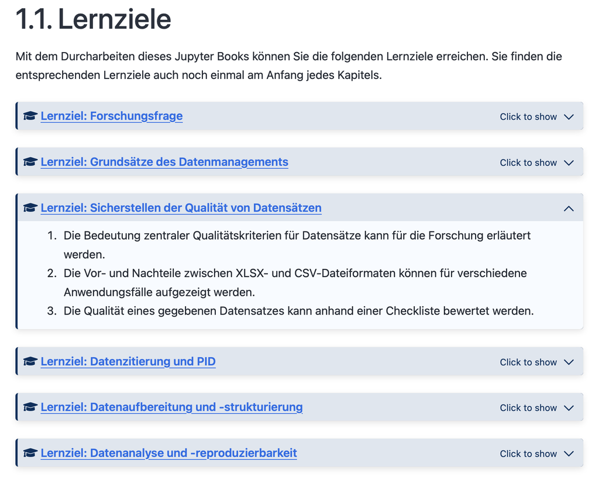

Component *1 Presentation of Questions/Problems/Tasks*

### Margin Notes

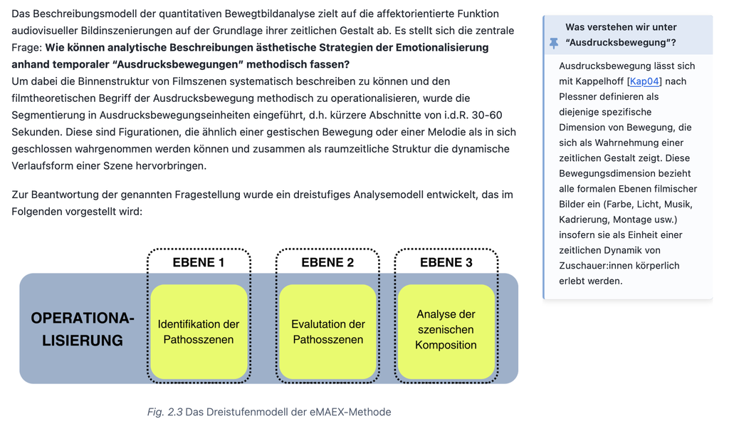

Components *2 Supporting Information* and *5 Procedural Information*

### Quizzes

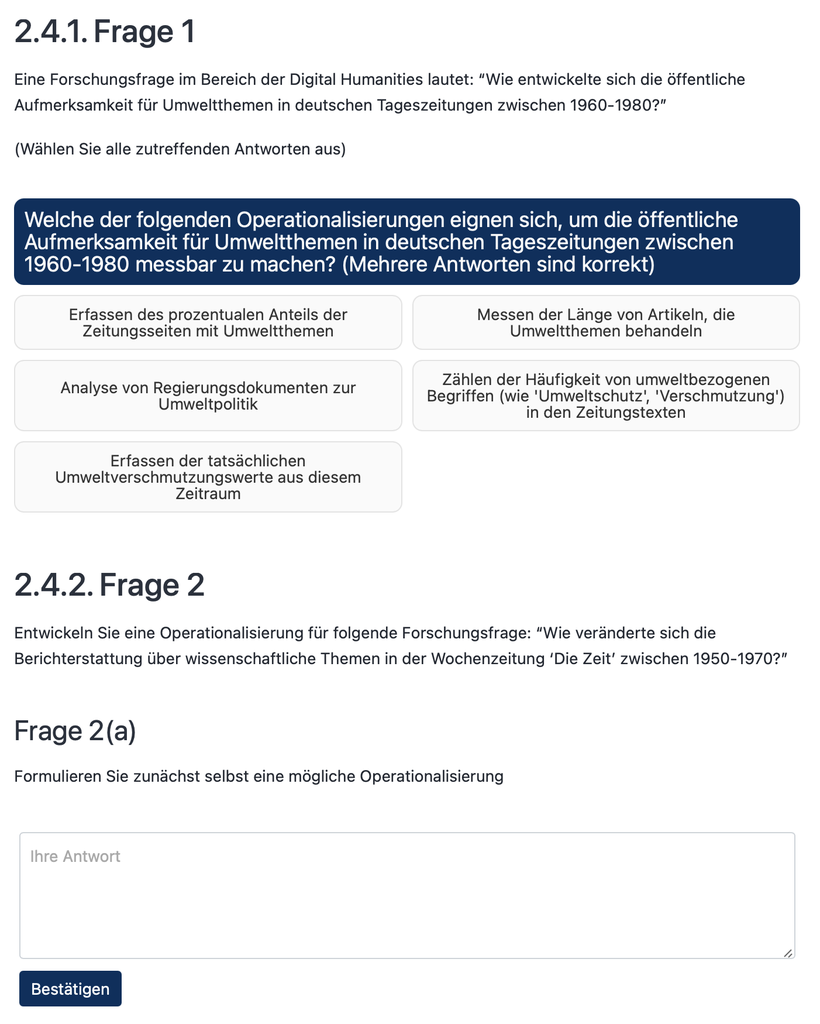

Components *3 Interactive Exercises* and *6 Assessment*

### Mandatory Chapters

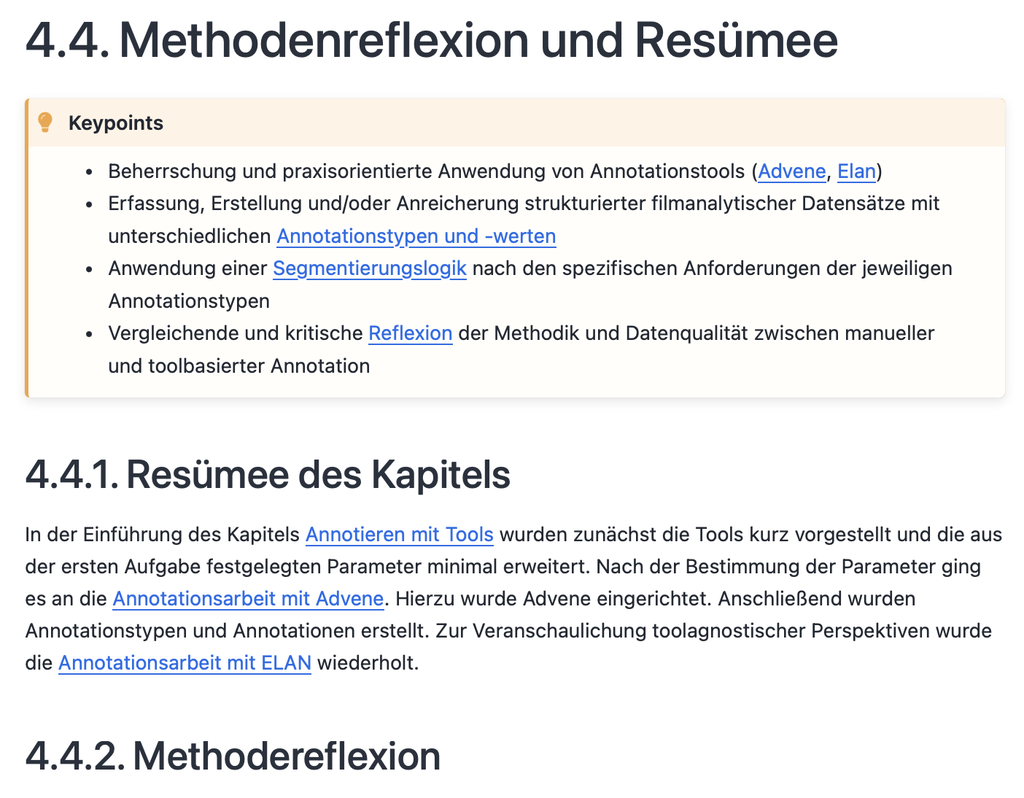

## Python Scripts

- Color Definitions (for Jupyter Quiz)
- Metadata Handling

### Metadata Scripts

[figure not shown]

## GitHub Actions & Pages

- GitHub Pages
- GitHub Actions
  - Metadata
  - Building the Book

### GitHub Actions

[figure not shown]

## Using Git

- Basic Git usage is viable for everyone.
- Avoid situations where manual merging is necessary.
- If manual merge is necessary, provide support.

## Zenodo Integration

- Connect GitHub and Zenodo
- Create version tag and then create release
- Automatic preprocessing and updating of metadata
- Zenodo creates publication

## Metadata

`metadata.yml`

https://quadriga-dk.github.io/quadriga-schema/

## First Steps

- Use `quadriga-dk/Book_Template` as a template for your OER, or
- Download the `.zip` as a starting point for your OER.

# Future Work

## Enhancing QUADRIGA Scripts

- enhance metadata handling
- maybe tool in the style of teachbooks

## Evaluation

- User Testing
  - Learners
  - Teachers
  - Authors
- Evaluation of learning outcomes

## More Assessment Options

- Drag‘n‘drop quizzes to allow for mapping and ordering exercises
- Interactive plot based assessment
- Better support for test-driven assessment

## Jupyter Book 2

- Re-architecture based on MyST.md instead of sphinx
- Depending on upgrade tooling, the finished case studies will be ported
- Bifurcation of template for both versions possible

## Slides

[figure not shown]

https://github.com/schnaitter/slides_jupyter_template_rdsc_informatik_2025

# References

Samoilova, Evgenia, Henny Sluyter-Gäthje, Daniil Skorinkin, Hannes Schnaitter, Peer Trilcke, and Ulrike Lucke. 2024. “Forschungsgeleitete Vermittlung von Datenkompetenz: Mediendidaktische Aufbereitung von Fallstudien Zu Bildungsangeboten.” In *INFORMATIK 2024*, 2153–66. Bonn: Gesellschaft für Informatik e.V. https://doi.org/10.18420/inf2024_187.

# Project Partners & Funding

## QUADRIGA

[figure not shown]

[QUADRIGA Projektwebsite](https://www.quadriga-dk.de)

[figure not shown]

https://quadriga-dk.github.io/qr

## Funding

Das Datenkompetenzzentrum QUADRIGA wird vom Bundesministerium für Forschung, Technologie und Raumfahrt (BMFTR) unter dem Kennzeichen 16DKZ2034 gefördert. Zu den Verbundpartern zählen:

- Universität Potsdam (Verbundkoordination) (Förderkennzeichen: 16DKZ2034A)
- Filmuniversität Babelsberg (Förderkennzeichen: 16DKZ2034B)
- Fachhochschule Potsdam (Förderkennzeichen: 16DKZ2034C)
- Fraunhofer FOKUS (Förderkennzeichen: 16DKZ2034D)
- Freie Universität Berlin (Förderkennzeichen: 16DKZ2034E)
- Technische Universität Berlin (Förderkennzeichen: 16DKZ2034F)
- Gesellschaft für Informatik (Förderkennzeichen: 16DKZ2034G)
- Humboldt-Universität zu Berlin (Förderkennzeichen: 16DKZ2034H)